# Intro to Introductory Statistics

9/13/2021

## Definition of Statistics

- A “statistic” is a number that summarizes data.
- An average is an example of a statistic.
- In Statistics, we think deeply about:
  - collection of data
  - summarization of data (with statistics)
  - conclusions we can draw from data.
- Statistics is the language, tools, and logic of research.
- Statistics is quantitative epistemology - the study of knowledge itself.
- How should someone update their beliefs when provided new information?
- How should someone use data to make predictions?

## Inference, soup

- In Statistics, our final goal is inference.
- From a small **sample**, we infer about a larger **population**.
- A chef tastes soup with a spoon:
  - The spoonful is a sample.
  - The statistic = “delicious”.
  - The chef infers the whole soup tastes delicious.
  - Hopefully the sample (spoon) was **representative** of the population (pot).

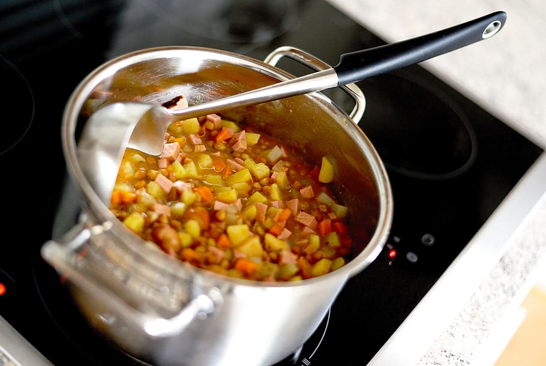

## Archery example

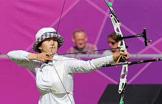

Creative Commons Attribution-Share Alike 2.0 Generic license.  
Attribution: Korea.net / Korean Culture and Information Service

- sample = 12 shots
- population = infinite potential shots under these conditions
- inference = should this archer adjust her aim?

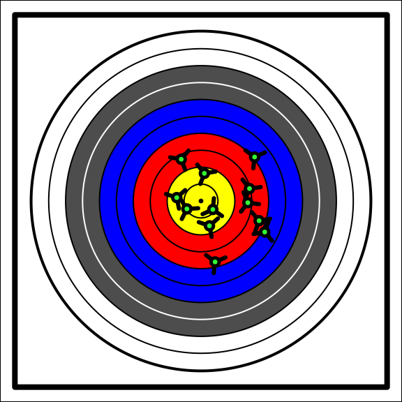

- statistics: \[\bar{x}=37\text{ mm}\] \[s_x=56.6\text{ mm}\]

## Basketball freethrows example

- In 2020-21 regular season, Chris Paul attempted 181 freethrows and made 169 of them (93.4%).
- Damian Lillard attempted 483 and made 448 of them (92.8%).
- Can we conclusively say Chris Paul is a better freethrow shooter?

```
##
##  2-sample test for equality of proportions with continuity correction
##
## data:  c(169, 448) out of c(181, 483)
## X-squared = 0.011223, df = 1, p-value = 0.9156
## alternative hypothesis: two.sided
## 95 percent confidence interval:
##  -0.04062479  0.05295564
## sample estimates:
##    prop 1    prop 2
## 0.9337017 0.9275362
```

2 samples: the attempts. 2 populations: the infinite potential attempts. The inference: it is very plausible that chance accounts for the difference.

## Correlation is not causation

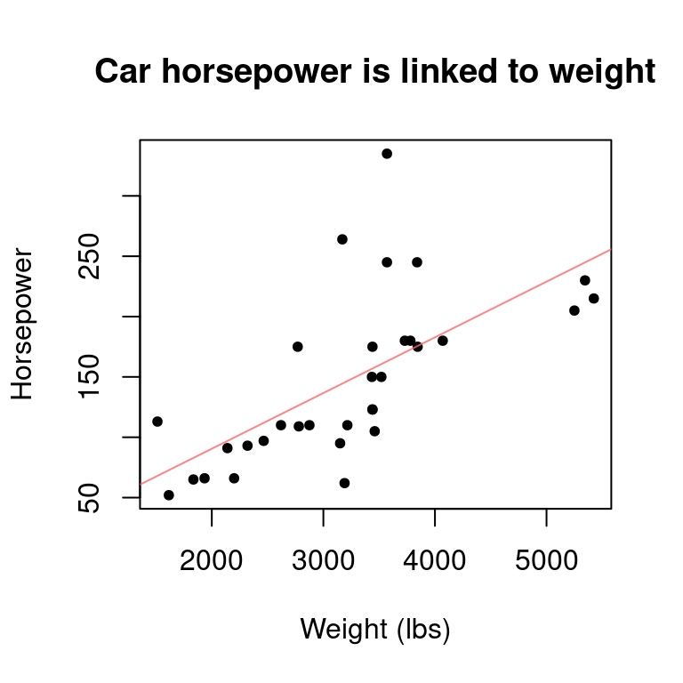

- Sample = 32 cars from 1974 Motor Trend magazine
- Population = all cars (from 1974)
- Inference = weight and hp are positively correlated
- Cars that weigh more tend to use higher horsepower.
- However, you won’t increase the horsepower by filling a car with bricks.

## Types of data

- **Binary**
  - 2 options: yes/no, success/fail, 0/1, orange/not orange
- **Discrete**
  - limited numerical options: dice rolls, # stairs between floors
  - [count noun](https://en.wikipedia.org/wiki/Count_noun), “how many”
- **Continuous**
  - infinite numerical options: exact timing, exact distance
  - [mass noun](https://en.wikipedia.org/wiki/Mass_noun), “how much”
- **Categorical** (not examined much in introductory stats)
  - 2 or more nonnumeric options: favorite color

## Binary spinner

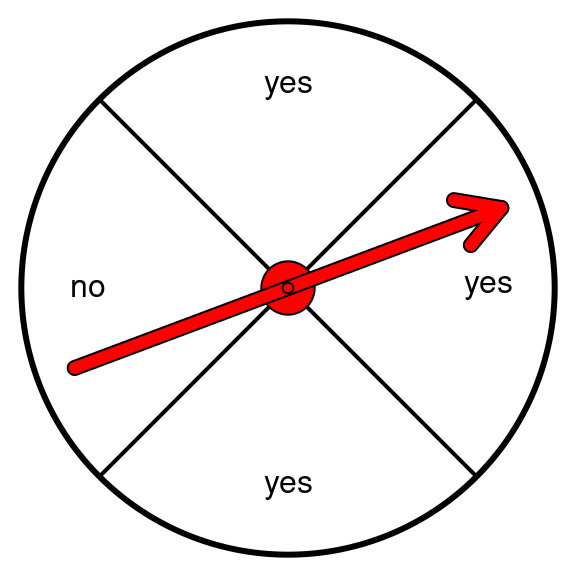

Population = the infinite potential spins Population parameters: \[\text{population proportion} = p = 0.75\]

As an example, imagine spinning 10 times.

Sample: 1, 0, 1, 0, 0, 1, 1, 0, 1, 1

Sample statistics: \[\text{sample size} = n = 10\] \[\text{sample success count} = 6\] \[\text{sample proportion} = \hat{p} = 0.6 \]

## Discrete spinner

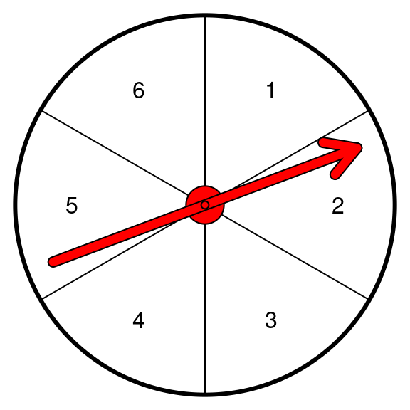

- population mean (unit 2) \[\mu = 3.5\]
- population standard deviation (unit 2) \[\sigma = 1.7078251\]
- sample \[3, 6, 3, 2, 2, 6, 3, 5, 4, 6\]
- sample size \[n=10\]
- sample total (sample sum) \[\sum{x} = 40\]
- sample mean \[\bar{x} = 4\]
- sample standard deviation \[s = 1.63\]

## Continuous spinner

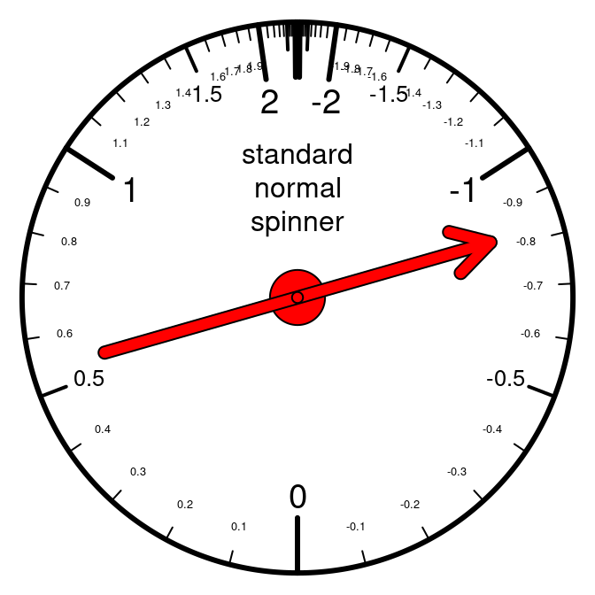

- population mean (unit 3) \[\mu = 0\]
- population standard deviation (unit 3) \[\sigma = 1\]
- sample: -1.2070657, 0.2774292, 1.0844412, -2.3456977, 0.4291247, 0.5060559, -0.57474, -0.5466319, -0.564452, -0.8900378
- sample size \[n=10\]
- sample total (sample sum) \[\sum{x} = -3.8315741\]
- sample mean \[\bar{x} = -0.3831574\]
- sample standard deviation \[s = 0.9958\]

## Histogram and frequency table

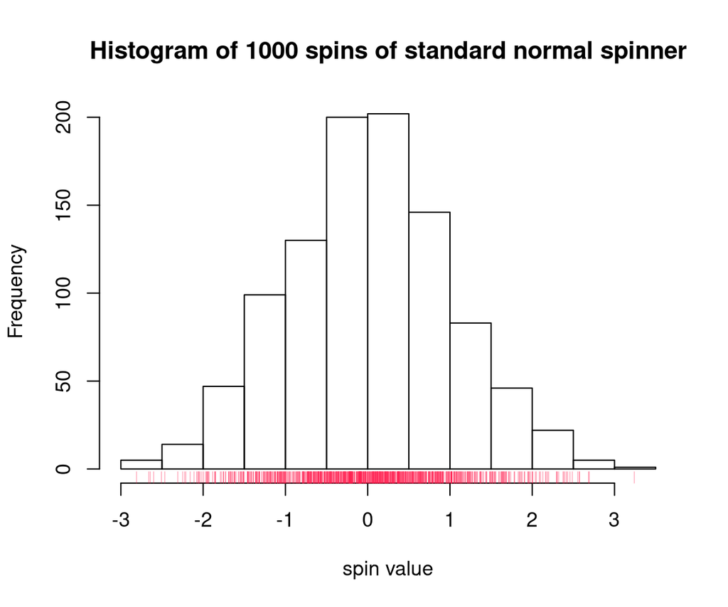

| interval | frequency |
| --- | --- |
| -3 to -2.5 | 5 |
| -2.5 to -2 | 14 |
| -2 to -1.5 | 47 |
| -1.5 to -1 | 99 |
| -1 to -0.5 | 130 |
| -0.5 to 0 | 200 |
| 0 to 0.5 | 202 |
| 0.5 to 1 | 146 |
| 1 to 1.5 | 83 |
| 1.5 to 2 | 46 |
| 2 to 2.5 | 22 |
| 2.5 to 3 | 5 |
| 3 to 3.5 | 1 |

## Dice hist and freq tab

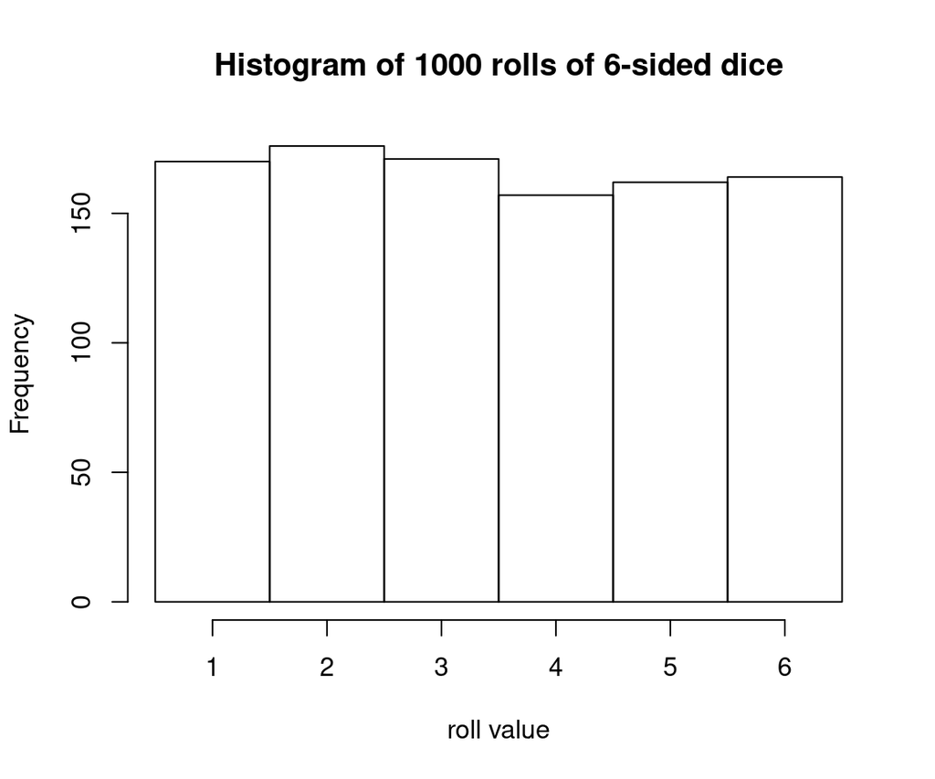

| interval | frequency |
| --- | --- |
| 0.5 to 1.5 | 170 |
| 1.5 to 2.5 | 176 |
| 2.5 to 3.5 | 171 |
| 3.5 to 4.5 | 157 |
| 4.5 to 5.5 | 162 |
| 5.5 to 6.5 | 164 |

## Notation reference

\(n\) = sample size, how many measurements

\(\#(\ldots)\) = how many measurements satisfy \(\ldots\) criterion. (nonstandard notation)

- Binary
  - \(p\) = population proportion
  - \(\hat{p}\) = “p hat” = sample proportion
- Discrete
  - \(\mu\) = “mu” = population mean
  - \(\sigma\) = “sigma” = population standard deviation
  - \(\sum x\) = “sum of x” = sample total
  - \(\bar{x}\) = “x bar” = sample mean
  - \(s\) = sample standard deviation (with Bessel correction by default)
- Probability
  - \(P(\ldots)\) = probability that \(\ldots\) happens